# STA237-hw1

Collin Kennedy and Qianhui Wan

10/1/2021

# Problem 2:

## 1) Plot the data;

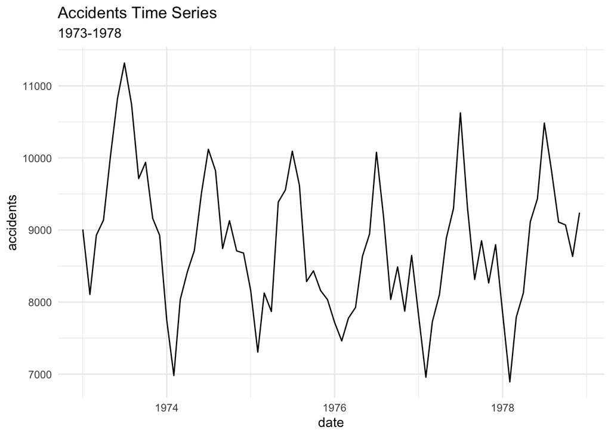

```r
accidents_ts = ts(data = accidents_data, start = c(1973,1), end = c(1978,12), frequency = 12)


accidents_data = accidents_data %>%
  mutate(date = seq.Date(from = my("011973"),to = my("121978"),by = "month"))


ggplot(data = accidents_data, mapping = aes(x = date,y=accidents))+
  geom_line()+
  ggtitle(label = "Accidents Time Series", subtitle = "1973-1978")+
  theme_minimal()
```

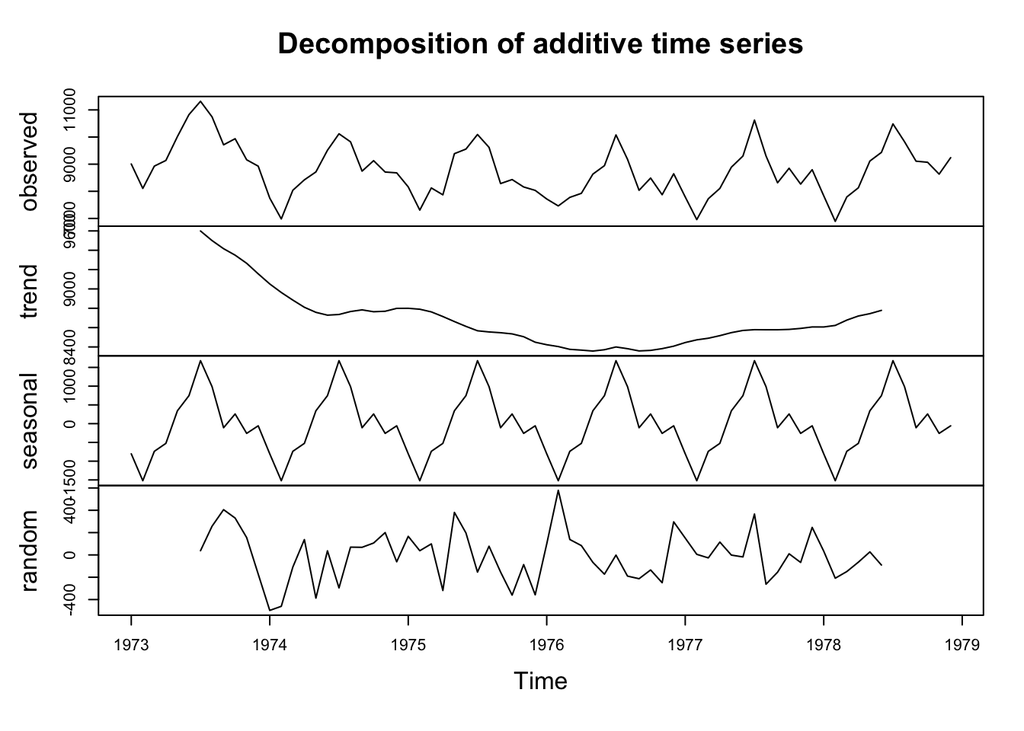

```r
ts_components = decompose(accidents_ts)

plot(ts_components)
```

```r
#we need to detrend before we can deseasonalize, correct? YES
#manually doing the decomposition:
accidents_data = accidents_data %>%
  mutate(year = format(date, "%Y")) %>%
  mutate(month = month(date))



accidents_transposed = accidents_data %>%
  select(accidents,year,month) %>%
  group_by(year) %>%
  summarise(mj_hat = mean(accidents))


full_accidents_df = accidents_data %>%
  select(-date) %>%
  pivot_wider(names_from = month,values_from = accidents) %>%
  left_join(accidents_transposed) %>%
  mutate(jan_diff = `1` - mj_hat) %>%
  mutate(feb_diff = `2` - mj_hat) %>%
  mutate(march_diff = `3` - mj_hat) %>%
  mutate(april_diff = `4` - mj_hat) %>%
  mutate(may_diff = `5` - mj_hat) %>%
  mutate(june_diff = `6` - mj_hat) %>%
  mutate(july_diff = `7` - mj_hat) %>%
  mutate(aug_diff = `8` - mj_hat) %>%
  mutate(sept_diff = `9`- mj_hat) %>%
  mutate(oct_diff = `10` - mj_hat) %>%
  mutate(nov_diff = `11` - mj_hat) %>%
  mutate(dec_diff = `12` - mj_hat) %>%
  summarise(jan_comp = mean(jan_diff),feb_comp = mean(feb_diff),
            march_comp = mean(march_diff), april_comp = mean(april_diff),
            may_comp = mean(may_diff), june_comp = mean(june_diff),
            july_comp = mean(july_diff), aug_comp = mean(aug_diff),
            sept_comp = mean(sept_diff), oct_comp = mean(oct_diff),
            nov_comp = mean(nov_diff), dec_comp = mean(dec_diff))
#confirmed manually




ts_components$seasonal
```

```
##              Jan         Feb         Mar         Apr         May         Jun
## 1973  -804.31944 -1521.73611  -737.46944  -525.81111   343.42222   746.41389
## 1974  -804.31944 -1521.73611  -737.46944  -525.81111   343.42222   746.41389
## 1975  -804.31944 -1521.73611  -737.46944  -525.81111   343.42222   746.41389
## 1976  -804.31944 -1521.73611  -737.46944  -525.81111   343.42222   746.41389
## 1977  -804.31944 -1521.73611  -737.46944  -525.81111   343.42222   746.41389
## 1978  -804.31944 -1521.73611  -737.46944  -525.81111   343.42222   746.41389
##              Jul         Aug         Sep         Oct         Nov         Dec
## 1973  1679.96389   986.83889  -108.76944   258.30556  -259.37778   -57.46111
## 1974  1679.96389   986.83889  -108.76944   258.30556  -259.37778   -57.46111
## 1975  1679.96389   986.83889  -108.76944   258.30556  -259.37778   -57.46111
## 1976  1679.96389   986.83889  -108.76944   258.30556  -259.37778   -57.46111
## 1977  1679.96389   986.83889  -108.76944   258.30556  -259.37778   -57.46111
## 1978  1679.96389   986.83889  -108.76944   258.30556  -259.37778   -57.46111
```

## 3) Plot the deseasonalized data

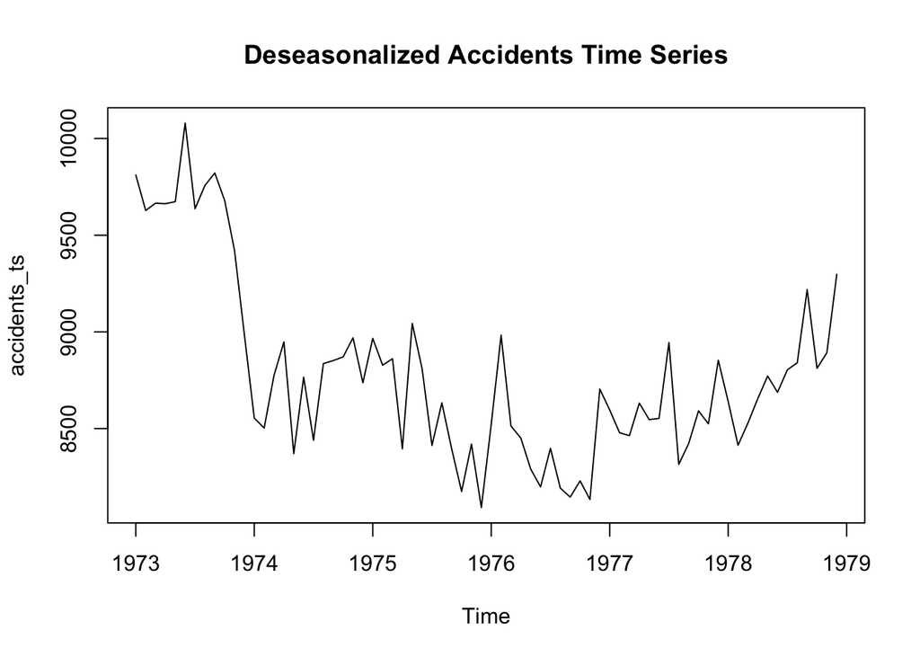

```r
deseasonalized_ts = accidents_ts - ts_components$seasonal

plot(deseasonalized_ts, main = "Deseasonalized Accidents Time Series")
```

## 4) Fit a suitable polynomial by least squares to the deseasonalized data and use it as your estimate ˆmt of mt;

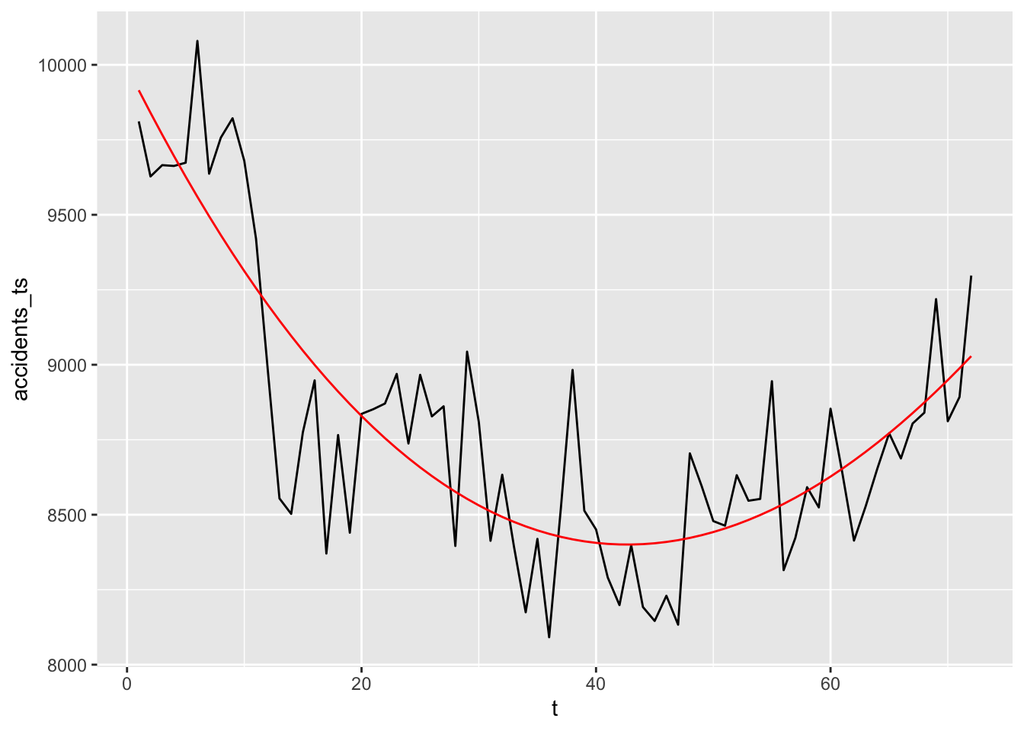

```r
#get the fitted values from the polynomial model then plot that:
#fit a polynomial of order n = 3

poly_model = lm(accidents_ts ~ poly(t,3),data = deseasonalized_ts_df)
deseasonalized_ts_df = deseasonalized_ts_df %>%
  mutate(poly_fitted_values = poly_model$fitted.values)
ggplot(data = deseasonalized_ts_df, mapping =aes(x = t, y = accidents_ts))+
  geom_line()+
  geom_line(color = 'red', data = deseasonalized_ts_df, mapping = aes(x = t, y = poly_fitted_values ))
```

Here I plot a polynomial of order 3. It appears to fit the overall trend of the data without overfitting.

## 5) Plot the residuals

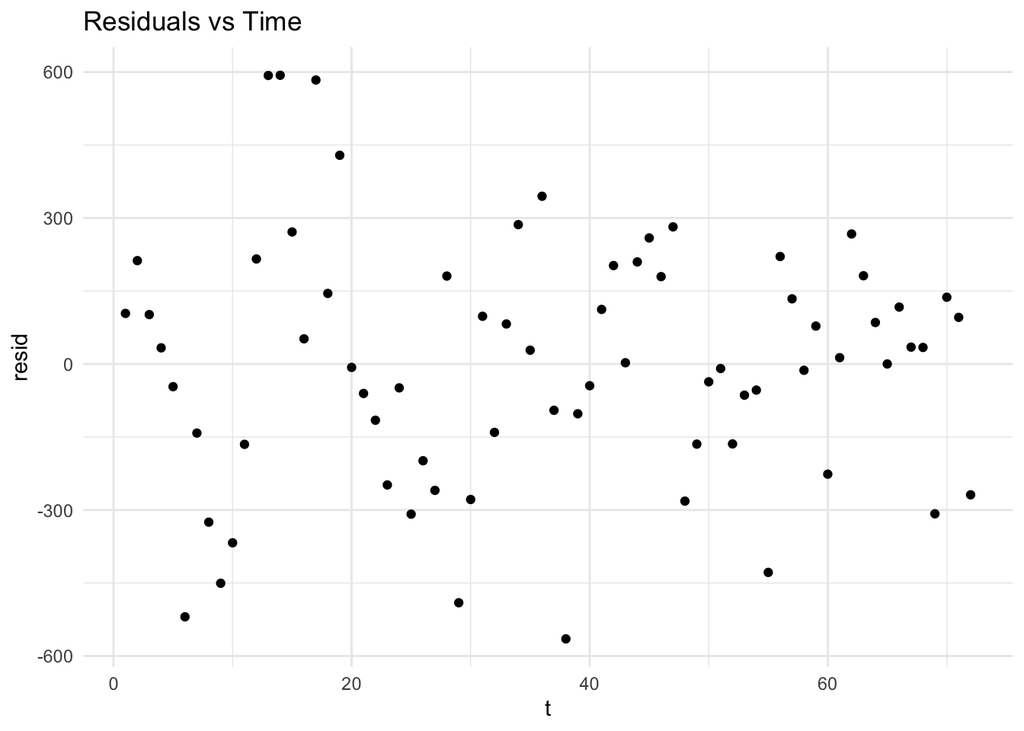

```r
#note that accidents_ts is already adjusted for the seasonal component
deseasonalized_ts_df = deseasonalized_ts_df %>%
  mutate(resid = poly_fitted_values - accidents_ts) %>%
  mutate(std_residuals = resid/sd(resid))

ggplot(data = deseasonalized_ts_df, mapping = aes(x = t, y = resid))+
  geom_point()+
  ggtitle(label = "Residuals vs Time")+
  theme_minimal()
```

The residuals appear to be somewhat randomly distributed about 0, indicating constant variance.

## 6) Compute the sample ACF of the residuals

```r
acf(deseasonalized_ts_df$resid,plot = F)
```

```
##
## Autocorrelations of series 'deseasonalized_ts_df$resid', by lag
##
##      0      1      2      3      4      5      6      7      8      9     10
##  1.000  0.382  0.230  0.144 -0.091 -0.047 -0.175 -0.340 -0.337 -0.211 -0.215
##     11     12     13     14     15     16     17     18
## -0.099 -0.084 -0.143  0.044  0.007  0.020  0.189 -0.004
```

## 7) Use your fitted model to predict Xt

```r
#Right now I've essentially regressed  seasonally adjusted accidents on an nth order polynomial. is that correct??


new_data = seq(from = 73, to = 84, by = 1)
new_data = tibble(t = new_data)
model_predictions = predict(poly_model,newdata = new_data)
```

Our third order polynomial model predicts the following number of accidents for t = 73,…, 84: 9070.3521895, 9113.2717417, 9157.3914101, 9202.6991432, 9249.1828897, 9296.830598, 9345.6302169, 9395.5696948, 9446.6369803, 9498.8200221, 9552.1067687, 9606.4851687

# Problem 3: Testing the Residuals

## Method 1: Sample ACF

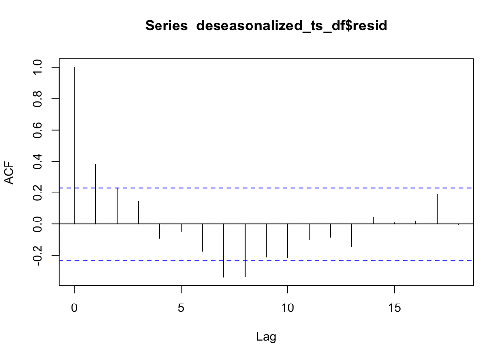

```r
acf(deseasonalized_ts_df$resid)
```

## Method 2: Portmanteau Test

$H_{0}$: independent and identically distributed residuals

$H_{a}$: the residuals are not independent and identically distributed

```r
Box.test(deseasonalized_ts_df$resid, type = "Ljung-Box", fitdf = 0)
```

```
##
##  Box-Ljung test
##
## data:  deseasonalized_ts_df$resid
## X-squared = 10.961, df = 1, p-value = 0.0009307
```

```r
acf_values = acf(deseasonalized_ts_df$resid,plot = F)$acf

acf(deseasonalized_ts_df$resid,plot = F)
```

```
##
## Autocorrelations of series 'deseasonalized_ts_df$resid', by lag
##
##      0      1      2      3      4      5      6      7      8      9     10
##  1.000  0.382  0.230  0.144 -0.091 -0.047 -0.175 -0.340 -0.337 -0.211 -0.215
##     11     12     13     14     15     16     17     18
## -0.099 -0.084 -0.143  0.044  0.007  0.020  0.189 -0.004
```

```r
sum_rho_squared = 0
for(i in 2:18){
  rho_i_squared = (acf_values[i])^2
  sum_rho_squared = sum_rho_squared + rho_i_squared

}
Q_statistic = 72*sum_rho_squared


Q_statistic > qchisq(.95,18)
```

```
## [1] TRUE
```

```r
p_value = pchisq(Q_statistic,18,lower.tail = FALSE)
```

We calculate a p-value of ~ 1.96554910^{-4}, which is < .05, so we reject the null hypothesis. We are a little concerned with this result given what we find with Methods 3 and 4 (where we fail to reject the null of iid residuals). The results seem contradictory but we are unsure as to why.

## Method 3: The Rank Test

$H_{0}$: residuals are independent and identically distributed

$H_{a}$: residuals are *not* independent and identically distributed

```r
rank_test_df = deseasonalized_ts_df %>%
  select(std_residuals) %>%
  mutate(i = seq(1,72,by = 1)) %>%
  mutate(j = seq(1,72,by = 1))

rank_test_df
```

```
## # A tibble: 72 x 3
##    std_residuals     i     j
##            <dbl> <dbl> <dbl>
##  1         0.415     1     1
##  2         0.847     2     2
##  3         0.405     3     3
##  4         0.132     4     4
##  5        -0.186     5     5
##  6        -2.07      6     6
##  7        -0.566     7     7
##  8        -1.30      8     8
##  9        -1.80      9     9
## 10        -1.47     10    10
## # … with 62 more rows
```

```r
random_pairs_df = tibble(std_residual_i = numeric(),std_residual_j = numeric(),i = numeric(),j = numeric())


for(i in 2:length(rank_test_df$std_residuals)){#start from the second row

  for(j in 1:length(rank_test_df$std_residuals)){

    if(rank_test_df[i,]$i > rank_test_df[j,]$j){
      #add that pair to the random_pairs_df
      random_pairs_df = random_pairs_df %>% add_row(std_residual_i = rank_test_df$std_residuals[[i]],
                                  std_residual_j = rank_test_df$std_residuals[[j]],
                                  i = rank_test_df$i[[i]],
                                  j = rank_test_df$j[[j]]
                                  )
    }else{
      break
    }

  }
}

#calculate Pi
random_pairs_df %>%
  mutate(res_i_greater_res_j = ifelse(std_residual_i > std_residual_j,1,0)) %>%
  summarise(pi = sum(res_i_greater_res_j)) #pi = 1307
```

```
## # A tibble: 1 x 1
##      pi
##   <dbl>
## 1  1307
```

```r
mu_pi = (1/4)*length(rank_test_df$std_residuals)*(length(rank_test_df$std_residuals)-1)
sigma_pi = (1/72)*length(rank_test_df$std_residuals)*(length(rank_test_df$std_residuals)-1)*(2*length(rank_test_df$std_residuals)+5)
sigma_pi
```

```
## [1] 10579
```

```r
mu_pi
```

```
## [1] 1278
```

```r
P_statistic = (1307 - mu_pi)/sigma_pi
P_statistic
```

```
## [1] 0.00274128
```

```r
P_statistic > 1.96
```

```
## [1] FALSE
```

Since our test statistic P = 0.0027413 *is not* $>$ 1.96, the corresponding normal distribution critical value at $\alpha$ = .05, we fail to reject the null hypothesis and conclude that the residuals are independent and identically distributed.

## Method 4: QQPlot (Test for Normality)

```r
#standardize the residuals first
deseasonalized_ts_df = deseasonalized_ts_df %>%
  mutate(std_residuals = resid/sd(resid))

deseasonalized_ts_df
```

```
## # A tibble: 72 x 5
##    accidents_ts     t poly_fitted_values  resid std_residuals
##           <dbl> <dbl>              <dbl>  <dbl>         <dbl>
##  1        9811.     1              9915.  104.          0.415
##  2        9628.     2              9840.  212.          0.847
##  3        9665.     3              9767.  102.          0.405
##  4        9663.     4              9696.   33.2         0.132
##  5        9674.     5              9627.  -46.6        -0.186
##  6       10080.     6              9560. -520.         -2.07
##  7        9637.     7              9495. -142.         -0.566
##  8        9757.     8              9432. -325.         -1.30
##  9        9822.     9              9371. -451.         -1.80
## 10        9680.    10              9312. -367.         -1.47
## # … with 62 more rows
```

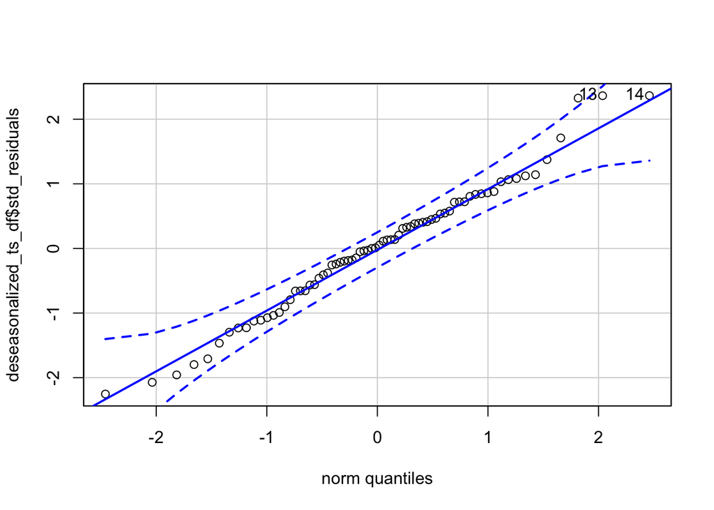

```
## [1] 14 13
```

```r
qqPlot(deseasonalized_ts_df$std_residuals)
```